# Exercise_4_Rueda_

## Exercise 4: Factor Variables, CPS-ORG/CPI Data Analysis, 1982-2024

### Plan

- **Data Preparation**: Initial setup and variable creation
- **Basic Wage Analysis**: Returns to education and experience
- **Extended Analysis**: Categorical variable effects on wages
- **Grade-Year Interactions**: Time variation in returns to education
- **Wage Inequality**: Analysis of education returns and wage differentials
- **Visualization**: Relationship between inequality and education returns

### Preliminaries

```stata
.     cd "~/OneDrive/ECO 727/Analysis"
C:\Users\melin\OneDrive\ECO 727\Analysis

.     set scheme s2color

.     global ex=4

.     global lname="Rueda"

.     global endyear=2024

.     global startyear=1982

.     global numyear=$endyear-$startyear+1
```

The preliminary setup establishes the working environment and defines global variables for the analysis period from 1982 to 2024.

### Data Preparation and Variable Creation

```stata
.     use "../Data/CPS-ORG with CPI, 1982-2024.dta", clear

.     keep if !mi(earnweek)
(36,949 observations deleted)
```

```stata
.     gen experience = age - grade + 6

.     drop if experience <=0
(0 observations deleted)

.     gen exp2 = (experience)^2

.     gen lrwage = log(rwage)
```

The initial dataset had 36,949 missing earnings observations that were removed. All individuals in the dataset had valid experience calculations (no negative values), indicating consistent age and education reporting.

### Basic Wage Analysis

```stata
.     regress lrwage grade experience exp2 [pw=earnwt]
(sum of wgt is 57,822,392,748.84)

Linear regression                               Number of obs     =  6,701,139
                                                F(3, 6701135)     >   99999.00
                                                Prob > F          =     0.0000
                                                R-squared         =     0.2323
                                                Root MSE          =     .68641

─────────────┬────────────────────────────────────────────────────────────────
             │               Robust
      lrwage │ Coefficient  std. err.      t    P>|t|     [95% conf. interval]
─────────────┼────────────────────────────────────────────────────────────────
       grade │   .1114197   .0001278   871.66   0.000     .1111691    .1116702
  experience │   .0798706   .0001496   533.81   0.000     .0795774    .0801639
        exp2 │  -.0009798   2.26e-06  -433.58   0.000    -.0009843   -.0009754
       _cons │   3.902655   .0028062  1390.71   0.000     3.897155    3.908155
─────────────┴────────────────────────────────────────────────────────────────

.     testparm experience exp2

 ( 1)  experience = 0
 ( 2)  exp2 = 0

       F(  2,6701135) = 2.8e+05
            Prob > F =    0.0000

.     display -(_b[experience]) / (2 * _b[exp2])
40.756651
```

Returns to education show approximately 11.1% increase in wages per year of schooling. Experience has a concave relationship with wages, peaking at about 41 years of experience, after which returns begin to decline. The model explains about 23.2% of wage variation.

### Extended Analysis with Categorical Variables

```stata
.     regress lrwage grade experience exp2 i.female i.race i.region ///
>            i.occupation i.industry i.year [pw=earnwt]
(sum of wgt is 57,822,392,748.84)

Linear regression                               Number of obs     =  6,701,139
                                                F(99, 6701039)    =   30393.95
                                                Prob > F          =     0.0000
                                                R-squared         =     0.3905
                                                Root MSE          =     .61162

───────────────────────┬────────────────────────────────────────────────────────────────
                       │               Robust
                lrwage │ Coefficient  std. err.      t    P>|t|     [95% conf. interval]
───────────────────────┼────────────────────────────────────────────────────────────────
                 grade │   .0799573   .0001499   533.51   0.000     .0796635     .080251
            experience │   .0625291   .0001356   460.98   0.000     .0622633     .062795
                  exp2 │  -.0007623   2.02e-06  -377.29   0.000    -.0007663   -.0007584
              1.female │  -.2910524   .0006542  -444.86   0.000    -.2923347   -.2897701
                       │
                  race │
           200. black  │  -.0679556    .000931   -72.99   0.000    -.0697804   -.0661308
300. american india..  │  -.0625069   .0033716   -18.54   0.000    -.0691151   -.0558986
650. asian or pacif..  │  -.0469965   .0025531   -18.41   0.000    -.0520005   -.0419926
      651. asian only  │   .0130101   .0019456     6.69   0.000     .0091969    .0168234
652. hawaiian/pacif..  │  -.0259989   .0067166    -3.87   0.000    -.0391631   -.0128346
700. other (single)..  │  -.0620522   .0031287   -19.83   0.000    -.0681843     -.05592
     801. white-black  │  -.0302916   .0075117    -4.03   0.000    -.0450143   -.0155689
802. white-american..  │  -.0506817   .0053423    -9.49   0.000    -.0611524   -.0402111
     803. white-asian  │   .0121735   .0091151     1.34   0.182    -.0056918    .0300387
804. white-hawaiian..  │  -.0016672    .016229    -0.10   0.918    -.0334755    .0301412
805. black-american..  │  -.0938029   .0147372    -6.37   0.000    -.1226873   -.0649184
     806. black-asian  │   .0346143   .0269073     1.29   0.198    -.0181231    .0873518
807. black-hawaiian..  │  -.0394979   .0569352    -0.69   0.488    -.1510888     .072093
808. american india..  │  -.0386702   .0550363    -0.70   0.482    -.1465394     .069199
809. asian-hawaiian..  │  -.0376902   .0170772    -2.21   0.027     -.071161   -.0042194
810. white-black-am..  │  -.0646014   .0192228    -3.36   0.001    -.1022774   -.0269254
811. white-black-as..  │   .0031404    .067837     0.05   0.963    -.1298178    .1360986
812. white-american..  │  -.0651473   .0657033    -0.99   0.321    -.1939235    .0636289
813. white-asian-ha..  │  -.0526007   .0165549    -3.18   0.001    -.0850477   -.0201537
814. white-black-am..  │   .0105223   .0640141     0.16   0.869     -.114943    .1359876
815. american india..  │  -.2681081    .100592    -2.67   0.008    -.4652649   -.0709513
816. white-black--h..  │  -.1303696   .1183779    -1.10   0.271    -.3623859    .1016468
817. white-american..  │  -.0922176    .070006    -1.32   0.188    -.2294268    .0449917
818. black-american..  │  -.1683233   .1459683    -1.15   0.249     -.454416    .1177694
819. white-american..  │    .264069    .102422     2.58   0.010     .0633255    .4648125
820. two or three r..  │  -.0173436   .0447013    -0.39   0.698    -.1049566    .0702694
830. four or five r..  │   -.038161   .0484374    -0.79   0.431    -.1330967    .0567746
                       │
                region │
middle atlantic div..  │   .0037052   .0012926     2.87   0.004     .0011717    .0062387
east north central ..  │  -.0490464   .0012371   -39.65   0.000     -.051471   -.0466218
west north central ..  │  -.0784041   .0013546   -57.88   0.000    -.0810591   -.0757491
south atlantic divi..  │  -.0332142   .0012254   -27.10   0.000     -.035616   -.0308124
east south central ..  │  -.1051666   .0014749   -71.30   0.000    -.1080575   -.1022758
west south central ..  │  -.0487101   .0013449   -36.22   0.000     -.051346   -.0460743
    mountain division  │  -.0445385   .0013908   -32.02   0.000    -.0472644   -.0418126
     pacific division  │   .0382837   .0012834    29.83   0.000     .0357683    .0407991
                       │
            occupation │
managers, officials..  │   .0997386   .0010229    97.50   0.000     .0977337    .1017436
    clerical, kindred  │  -.3325459   .0009907  -335.67   0.000    -.3344876   -.3306042
                sales  │  -.2138352   .0015488  -138.06   0.000    -.2168708   -.2107995
            craftsmen  │  -.1619581   .0011928  -135.78   0.000     -.164296   -.1596202
           operatives  │  -.3477286    .001225  -283.86   0.000    -.3501296   -.3453276
 service (private hh)  │  -.8202867   .0040197  -204.07   0.000    -.8281651   -.8124083
      service (other)  │  -.4808805   .0011574  -415.49   0.000    -.4831489   -.4786121
             laborers  │  -.4691708   .0016462  -285.00   0.000    -.4723974   -.4659442
                       │
              industry │
         construction  │   .0550638   .0022268    24.73   0.000     .0506993    .0594283
durable manufacturing  │   .1248019   .0021232    58.78   0.000     .1206405    .1289632
nondurable manufact..  │   .0690275   .0022309    30.94   0.000     .0646551       .0734
communications, tra..  │   .1247547   .0022498    55.45   0.000     .1203452    .1291643
      wholesale trade  │   .0467364   .0024459    19.11   0.000     .0419426    .0515302
         retail trade  │  -.2842677   .0021415  -132.74   0.000     -.288465   -.2800704
professional servic..  │   .0075811   .0021476     3.53   0.000      .003372    .0117903
education, welfare ..  │  -.3003735   .0022831  -131.57   0.000    -.3048482   -.2958987
public administration  │   .1360024    .002294    59.29   0.000     .1315063    .1404986
       other services  │  -.0903802   .0022104   -40.89   0.000    -.0947126   -.0860478
                       │
                  year │
                 1983  │   -.003701   .0021285    -1.74   0.082    -.0078728    .0004708
                 1984  │  -.0002415    .002116    -0.11   0.909    -.0043887    .0039057
                 1985  │  -.0002673   .0021041    -0.13   0.899    -.0043914    .0038567
                 1986  │   .0109947   .0021052     5.22   0.000     .0068686    .0151209
                 1987  │   .0088311   .0021093     4.19   0.000     .0046969    .0129652
                 1988  │    .000017    .002165     0.01   0.994    -.0042263    .0042602
                 1989  │   .0034682   .0021593     1.61   0.108     -.000764    .0077005
                 1990  │  -.0056801   .0020985    -2.71   0.007    -.0097932    -.001567
                 1991  │    -.02339   .0021233   -11.02   0.000    -.0275516   -.0192284
                 1992  │  -.0292635   .0021328   -13.72   0.000    -.0334438   -.0250832
                 1993  │  -.0332694   .0021478   -15.49   0.000     -.037479   -.0290598
                 1994  │   -.050491   .0022322   -22.62   0.000    -.0548661    -.046116
                 1995  │  -.0587822   .0022455   -26.18   0.000    -.0631834    -.054381
                 1996  │  -.0625177   .0022915   -27.28   0.000     -.067009   -.0580263
                 1997  │  -.0492832    .002254   -21.87   0.000    -.0537009   -.0448656
                 1998  │  -.0172879   .0022859    -7.56   0.000    -.0217682   -.0128076
                 1999  │   .0023167   .0022542     1.03   0.304    -.0021014    .0067348
                 2000  │    .016745   .0022495     7.44   0.000      .012336     .021154
                 2001  │   .0192511   .0022698     8.48   0.000     .0148024    .0236998
                 2002  │   .0216081   .0022498     9.60   0.000     .0171985    .0260178
                 2003  │    .020854    .002344     8.90   0.000     .0162599    .0254481
                 2004  │   .0217256   .0023074     9.42   0.000     .0172031     .026248
                 2005  │   .0132463   .0022882     5.79   0.000     .0087616    .0177311
                 2006  │   .0176108    .002259     7.80   0.000     .0131832    .0220384
                 2007  │   .0146316   .0023152     6.32   0.000      .010094    .0191692
                 2008  │   .0039653   .0023395     1.69   0.090    -.0006201    .0085507
                 2009  │  -.0014615   .0023845    -0.61   0.540     -.006135     .003212
                 2010  │  -.0124796   .0023976    -5.21   0.000    -.0171788   -.0077804
                 2011  │  -.0321543   .0023833   -13.49   0.000    -.0368256   -.0274831
                 2012  │   -.037968   .0024037   -15.80   0.000    -.0426792   -.0332569
                 2013  │  -.0335531   .0023848   -14.07   0.000    -.0382272   -.0288791
                 2014  │  -.0320223   .0023623   -13.56   0.000    -.0366524   -.0273922
                 2015  │  -.0080478   .0023914    -3.37   0.001    -.0127349   -.0033608
                 2016  │   .0072976   .0023769     3.07   0.002     .0026389    .0119563
                 2017  │   .0193011   .0023967     8.05   0.000     .0146036    .0239986
                 2018  │   .0249395   .0024149    10.33   0.000     .0202065    .0296726
                 2019  │   .0468072   .0024498    19.11   0.000     .0420056    .0516088
                 2020  │   .0733847   .0025884    28.35   0.000     .0683116    .0784578
                 2021  │   .0707344   .0025084    28.20   0.000     .0658181    .0756508
                 2022  │   .0502116   .0025335    19.82   0.000      .045246    .0551772
                 2023  │   .0731941   .0026818    27.29   0.000      .067938    .0784503
                 2024  │    .105967    .003309    32.02   0.000     .0994814    .1124526
                       │
                 _cons │   5.056874   .0041077  1231.08   0.000     5.048823    5.064925
───────────────────────┴────────────────────────────────────────────────────────────────
```

```stata
.     testparm i.race

 ( 1)  200.race = 0
 ( 2)  300.race = 0
 ( 3)  650.race = 0
 ( 4)  651.race = 0
 ( 5)  652.race = 0
 ( 6)  700.race = 0
 ( 7)  801.race = 0
 ( 8)  802.race = 0
 ( 9)  803.race = 0
 (10)  804.race = 0
 (11)  805.race = 0
 (12)  806.race = 0
 (13)  807.race = 0
 (14)  808.race = 0
 (15)  809.race = 0
 (16)  810.race = 0
 (17)  811.race = 0
 (18)  812.race = 0
 (19)  813.race = 0
 (20)  814.race = 0
 (21)  815.race = 0
 (22)  816.race = 0
 (23)  817.race = 0
 (24)  818.race = 0
 (25)  819.race = 0
 (26)  820.race = 0
 (27)  830.race = 0

       F( 27,6701039) =  238.20
            Prob > F =    0.0000

.     testparm i.region

 ( 1)  12.region = 0
 ( 2)  21.region = 0
 ( 3)  22.region = 0
 ( 4)  31.region = 0
 ( 5)  32.region = 0
 ( 6)  33.region = 0
 ( 7)  41.region = 0
 ( 8)  42.region = 0

       F(  8,6701039) = 2493.06
            Prob > F =    0.0000

.     testparm i.occupation

 ( 1)  2.occupation = 0
 ( 2)  3.occupation = 0
 ( 3)  4.occupation = 0
 ( 4)  5.occupation = 0
 ( 5)  6.occupation = 0
 ( 6)  7.occupation = 0
 ( 7)  8.occupation = 0
 ( 8)  9.occupation = 0

       F(  8,6701039) =49139.86
            Prob > F =    0.0000

.     testparm i.industry

 ( 1)  2.industry = 0
 ( 2)  3.industry = 0
 ( 3)  4.industry = 0
 ( 4)  5.industry = 0
 ( 5)  6.industry = 0
 ( 6)  7.industry = 0
 ( 7)  8.industry = 0
 ( 8)  9.industry = 0
 ( 9)  10.industry = 0
 (10)  11.industry = 0

       F( 10,6701039) =29220.72
            Prob > F =    0.0000

.     testparm i.year

 ( 1)  1983.year = 0
 ( 2)  1984.year = 0
 ( 3)  1985.year = 0
 ( 4)  1986.year = 0
 ( 5)  1987.year = 0
 ( 6)  1988.year = 0
 ( 7)  1989.year = 0
 ( 8)  1990.year = 0
 ( 9)  1991.year = 0
 (10)  1992.year = 0
 (11)  1993.year = 0
 (12)  1994.year = 0
 (13)  1995.year = 0
 (14)  1996.year = 0
 (15)  1997.year = 0
 (16)  1998.year = 0
 (17)  1999.year = 0
 (18)  2000.year = 0
 (19)  2001.year = 0
 (20)  2002.year = 0
 (21)  2003.year = 0
 (22)  2004.year = 0
 (23)  2005.year = 0
 (24)  2006.year = 0
 (25)  2007.year = 0
 (26)  2008.year = 0
 (27)  2009.year = 0
 (28)  2010.year = 0
 (29)  2011.year = 0
 (30)  2012.year = 0
 (31)  2013.year = 0
 (32)  2014.year = 0
 (33)  2015.year = 0
 (34)  2016.year = 0
 (35)  2017.year = 0
 (36)  2018.year = 0
 (37)  2019.year = 0
 (38)  2020.year = 0
 (39)  2021.year = 0
 (40)  2022.year = 0
 (41)  2023.year = 0
 (42)  2024.year = 0

       F( 42,6701039) =  334.75
            Prob > F =    0.0000
```

Adding demographic and employment characteristics substantially improved model fit, increasing R-squared to 39%. Female workers face a significant wage penalty of approximately 29.1%, while regional variations show workers in Pacific and Middle Atlantic divisions earning premiums compared to other regions.

### Industry and Occupation Effects Analysis

The regression results reveal significant variation across industries and occupations:

- **Industry Effects**: Public administration and durable manufacturing show the highest wage premiums (13.6% and 12.5% respectively), while retail trade and education/welfare services show substantial penalties (-28.4% and -30% respectively).
- **Occupation Effects**: Occupation effects reveal managers earning roughly 10% more than professionals, while service workers face the largest wage penalties.

All categorical variables (race, region, occupation, industry, and year) show strong joint statistical significance (p < 0.001).

### Grade-Year Interaction Analysis

```stata
.     regress lrwage year#c.grade experience exp2 i.year i.female i.race ///
>            i.region i.occupation i.industry [pw=earnwt]
(sum of wgt is 57,822,392,748.84)

Linear regression                               Number of obs     =  6,701,139
                                                F(141, 6700997)   =   21787.24
                                                Prob > F          =     0.0000
                                                R-squared         =     0.3912
                                                Root MSE          =     .61124

───────────────────────┬────────────────────────────────────────────────────────────────
                       │               Robust
                lrwage │ Coefficient  std. err.      t    P>|t|     [95% conf. interval]
───────────────────────┼────────────────────────────────────────────────────────────────
          year#c.grade │
                 1982  │   .0540075   .0005876    91.91   0.000     .0528558    .0551592
                 1983  │   .0573594   .0006034    95.07   0.000     .0561768    .0585419
                 1984  │   .0601585   .0006076    99.00   0.000     .0589676    .0613495
                 1985  │   .0623461   .0006096   102.27   0.000     .0611513     .063541
                 1986  │   .0658227   .0006156   106.93   0.000     .0646162    .0670292
                 1987  │   .0677575   .0006212   109.07   0.000     .0665399    .0689751
                 1988  │   .0663698   .0006558   101.21   0.000     .0650846    .0676551
                 1989  │   .0728991   .0007019   103.86   0.000     .0715233    .0742748
                 1990  │   .0739098   .0006369   116.05   0.000     .0726616     .075158
                 1991  │    .073983   .0006289   117.65   0.000     .0727505    .0752156
                 1992  │   .0791989    .000666   118.91   0.000     .0778935    .0805042
                 1993  │   .0810902   .0006942   116.81   0.000     .0797296    .0824508
                 1994  │   .0845855   .0007167   118.02   0.000     .0831808    .0859902
                 1995  │   .0833785   .0007197   115.85   0.000     .0819679    .0847891
                 1996  │   .0821579     .00076   108.10   0.000     .0806683    .0836475
                 1997  │   .0811896   .0007299   111.23   0.000      .079759    .0826203
                 1998  │   .0837288   .0007275   115.10   0.000      .082303    .0851546
                 1999  │   .0841275   .0006934   121.32   0.000     .0827685    .0854866
                 2000  │   .0827589   .0006972   118.70   0.000     .0813924    .0841254
                 2001  │   .0839577   .0007223   116.23   0.000      .082542    .0853734
                 2002  │   .0838785   .0006758   124.13   0.000      .082554    .0852029
                 2003  │   .0805367   .0007411   108.67   0.000     .0790841    .0819893
                 2004  │   .0808281   .0007132   113.34   0.000     .0794304    .0822259
                 2005  │   .0823374   .0006906   119.22   0.000     .0809838    .0836911
                 2006  │   .0814081   .0006827   119.25   0.000     .0800701    .0827461
                 2007  │   .0827895    .000716   115.63   0.000     .0813862    .0841928
                 2008  │   .0847264   .0007373   114.92   0.000     .0832814    .0861714
                 2009  │     .08676   .0007551   114.91   0.000     .0852801    .0882399
                 2010  │   .0889685   .0007654   116.24   0.000     .0874683    .0904687
                 2011  │   .0886514   .0007598   116.68   0.000     .0871623    .0901406
                 2012  │   .0888762   .0007817   113.70   0.000     .0873441    .0904083
                 2013  │   .0897974   .0007583   118.43   0.000     .0883113    .0912836
                 2014  │   .0873634   .0007283   119.95   0.000      .085936    .0887909
                 2015  │   .0859831   .0007576   113.49   0.000     .0844982    .0874681
                 2016  │   .0863203   .0007492   115.22   0.000     .0848519    .0877887
                 2017  │   .0837947    .000751   111.58   0.000     .0823228    .0852667
                 2018  │   .0815242   .0007616   107.05   0.000     .0800315    .0830168
                 2019  │   .0817342   .0007797   104.83   0.000     .0802061    .0832623
                 2020  │   .0806633    .000862    93.57   0.000     .0789737    .0823529
                 2021  │   .0785744    .000821    95.71   0.000     .0769653    .0801835
                 2022  │   .0775568   .0008417    92.14   0.000      .075907    .0792066
                 2023  │   .0808328   .0008931    90.51   0.000     .0790823    .0825833
                 2024  │   .0905608   .0011794    76.79   0.000     .0882493    .0928724
                       │
            experience │   .0625107   .0001356   460.88   0.000     .0622449    .0627766
                  exp2 │  -.0007631   2.02e-06  -377.51   0.000    -.0007671   -.0007592
                       │
                  year │
                 1983  │   -.044809    .010891    -4.11   0.000    -.0661549    -.023463
                 1984  │  -.0766547   .0109638    -6.99   0.000    -.0981433   -.0551662
                 1985  │  -.1044074   .0110179    -9.48   0.000    -.1260021   -.0828127
                 1986  │  -.1374323   .0110888   -12.39   0.000     -.159166   -.1156986
                 1987  │  -.1643518   .0111603   -14.73   0.000    -.1862255   -.1424781
                 1988  │  -.1546917   .0115158   -13.43   0.000    -.1772623   -.1321211
                 1989  │  -.2358716   .0119704   -19.70   0.000    -.2593331     -.21241
                 1990  │  -.2581948   .0113154   -22.82   0.000    -.2803725   -.2360171
                 1991  │  -.2765381   .0112609   -24.56   0.000    -.2986092   -.2544671
                 1992  │  -.3508328   .0116224   -30.19   0.000    -.3736123   -.3280534
                 1993  │  -.3796895   .0119375   -31.81   0.000    -.4030865   -.3562924
                 1994  │  -.4431537   .0122091   -36.30   0.000    -.4670832   -.4192243
                 1995  │  -.4356123   .0122259   -35.63   0.000    -.4595746   -.4116499
                 1996  │  -.4231052   .0126229   -33.52   0.000    -.4478456   -.3983647
                 1997  │  -.3970073   .0123122   -32.25   0.000    -.4211387   -.3728759
                 1998  │  -.3987742   .0123278   -32.35   0.000    -.4229363   -.3746121
                 1999  │  -.3846352   .0119535   -32.18   0.000    -.4080636   -.3612067
                 2000  │   -.351928   .0120102   -29.30   0.000    -.3754676   -.3283883
                 2001  │  -.3655394   .0122899   -29.74   0.000    -.3896272   -.3414516
                 2002  │  -.3622332   .0118489   -30.57   0.000    -.3854566   -.3390099
                 2003  │  -.3181722   .0125272   -25.40   0.000     -.342725   -.2936194
                 2004  │  -.3212289   .0121897   -26.35   0.000    -.3451204   -.2973375
                 2005  │  -.3499988   .0120041   -29.16   0.000    -.3735265   -.3264712
                 2006  │  -.3331613   .0119098   -27.97   0.000    -.3565041   -.3098184
                 2007  │  -.3548715   .0122869   -28.88   0.000    -.3789533   -.3307896
                 2008  │   -.392068   .0125491   -31.24   0.000    -.4166639   -.3674722
                 2009  │  -.4254474   .0127945   -33.25   0.000    -.4505241   -.4003707
                 2010  │  -.4668625   .0128913   -36.22   0.000    -.4921291   -.4415959
                 2011  │  -.4824124   .0129077   -37.37   0.000    -.5077111   -.4571137
                 2012  │   -.491573   .0132081   -37.22   0.000    -.5174605   -.4656855
                 2013  │  -.5002529   .0129688   -38.57   0.000    -.5256713   -.4748345
                 2014  │  -.4653029   .0126228   -36.86   0.000    -.4900432   -.4405626
                 2015  │  -.4225269   .0129741   -32.57   0.000    -.4479558   -.3970981
                 2016  │  -.4120714   .0129001   -31.94   0.000    -.4373552   -.3867875
                 2017  │  -.3651709   .0129213   -28.26   0.000    -.3904962   -.3398457
                 2018  │  -.3279823   .0130398   -25.15   0.000    -.3535398   -.3024247
                 2019  │  -.3090856   .0133018   -23.24   0.000    -.3351567   -.2830146
                 2020  │  -.2676102   .0142718   -18.75   0.000    -.2955824   -.2396379
                 2021  │  -.2407648   .0139475   -17.26   0.000    -.2681014   -.2134282
                 2022  │  -.2468822   .0141928   -17.39   0.000    -.2746995   -.2190649
                 2023  │  -.2701799   .0147838   -18.28   0.000    -.2991557   -.2412042
                 2024  │  -.3752193   .0181965   -20.62   0.000    -.4108839   -.3395548
                       │
              1.female │  -.2922999   .0006543  -446.73   0.000    -.2935824   -.2910175
                       │
                  race │
           200. black  │  -.0686415   .0009306   -73.76   0.000    -.0704655   -.0668175
300. american india..  │  -.0598656   .0033758   -17.73   0.000    -.0664819   -.0532492
650. asian or pacif..  │  -.0485385   .0025558   -18.99   0.000    -.0535478   -.0435291
      651. asian only  │   .0084234   .0019517     4.32   0.000     .0045981    .0122486
652. hawaiian/pacif..  │  -.0252371   .0067157    -3.76   0.000    -.0383997   -.0120746
700. other (single)..  │  -.0541337   .0031132   -17.39   0.000    -.0602354    -.048032
     801. white-black  │  -.0291788   .0075091    -3.89   0.000    -.0438964   -.0144612
802. white-american..  │  -.0490416   .0053475    -9.17   0.000    -.0595226   -.0385606
     803. white-asian  │   .0086869   .0091046     0.95   0.340    -.0091578    .0265316
804. white-hawaiian..  │   -.002276   .0161762    -0.14   0.888    -.0339807    .0294287
805. black-american..  │  -.0935276   .0147484    -6.34   0.000    -.1224339   -.0646213
     806. black-asian  │   .0318263   .0268577     1.18   0.236    -.0208138    .0844664
807. black-hawaiian..  │  -.0381892   .0571145    -0.67   0.504    -.1501315    .0737532
808. american india..  │  -.0400125   .0548526    -0.73   0.466    -.1475217    .0674967
809. asian-hawaiian..  │  -.0387825   .0170616    -2.27   0.023    -.0722225   -.0053424
810. white-black-am..  │   -.064193   .0192482    -3.34   0.001    -.1019188   -.0264671
811. white-black-as..  │   .0003727   .0678026     0.01   0.996    -.1325179    .1332634
812. white-american..  │    -.06554   .0658422    -1.00   0.320    -.1945885    .0635084
813. white-asian-ha..  │  -.0528795   .0165649    -3.19   0.001    -.0853462   -.0204129
814. white-black-am..  │   .0096871   .0636553     0.15   0.879     -.115075    .1344493
815. american india..  │   -.268576   .1004877    -2.67   0.008    -.4655284   -.0716237
816. white-black--h..  │  -.1316006   .1183404    -1.11   0.266    -.3635436    .1003424
817. white-american..  │  -.0886633   .0700809    -1.27   0.206    -.2260194    .0486927
818. black-american..  │  -.1699235   .1453531    -1.17   0.242    -.4548104    .1149634
819. white-american..  │   .2620891   .1019015     2.57   0.010     .0623659    .4618124
820. two or three r..  │  -.0178392    .044777    -0.40   0.690    -.1056006    .0699221
830. four or five r..  │  -.0353939    .048645    -0.73   0.467    -.1307364    .0599485
                       │
                region │
middle atlantic div..  │   .0040378   .0012914     3.13   0.002     .0015067    .0065688
east north central ..  │  -.0485335    .001236   -39.27   0.000    -.0509559    -.046111
west north central ..  │  -.0780484   .0013536   -57.66   0.000    -.0807014   -.0753954
south atlantic divi..  │  -.0333557   .0012244   -27.24   0.000    -.0357554   -.0309559
east south central ..  │  -.1054848   .0014741   -71.56   0.000     -.108374   -.1025957
west south central ..  │  -.0478624   .0013442   -35.61   0.000     -.050497   -.0452279
    mountain division  │  -.0436024     .00139   -31.37   0.000    -.0463268   -.0408781
     pacific division  │   .0396882   .0012824    30.95   0.000     .0371747    .0422017
```

```stata
                       │
            occupation │
managers, officials..  │   .1001946   .0010219    98.05   0.000     .0981918    .1021974
    clerical, kindred  │  -.3307224   .0009915  -333.56   0.000    -.3326656   -.3287791
                sales  │  -.2123244   .0015485  -137.11   0.000    -.2153594   -.2092894
            craftsmen  │  -.1619938   .0011927  -135.82   0.000    -.1643314   -.1596562
           operatives  │   -.348232   .0012247  -284.34   0.000    -.3506324   -.3458316
 service (private hh)  │  -.8156434   .0040438  -201.70   0.000    -.8235691   -.8077176
      service (other)  │  -.4792818   .0011579  -413.92   0.000    -.4815513   -.4770123
             laborers  │  -.4692539   .0016466  -284.98   0.000    -.4724813   -.4660266
                       │
              industry │
         construction  │   .0552622   .0022291    24.79   0.000     .0508932    .0596312
durable manufacturing  │   .1227307    .002125    57.75   0.000     .1185657    .1268957
nondurable manufact..  │   .0667502   .0022329    29.89   0.000     .0623738    .0711266
communications, tra..  │   .1239371   .0022513    55.05   0.000     .1195247    .1283496
      wholesale trade  │   .0458961   .0024474    18.75   0.000     .0410994    .0506929
         retail trade  │  -.2848876   .0021435  -132.91   0.000    -.2890889   -.2806863
professional servic..  │   .0055892   .0021497     2.60   0.009     .0013758    .0098026
education, welfare ..  │  -.3012608   .0022847  -131.86   0.000    -.3057387   -.2967829
public administration  │    .134469   .0022959    58.57   0.000     .1299691     .138969
       other services  │  -.0923227   .0022126   -41.73   0.000    -.0966593   -.0879862
                       │
                 _cons │   5.390634   .0083357   646.69   0.000     5.374296    5.406972
───────────────────────┴────────────────────────────────────────────────────────────────
```

```stata
.     matrix b = e(b)[1, 1..$numyear]'

.     clear

.     svmat2 b, names(grade_coef) rnames(tag)
number of observations will be reset to 43
Press any key to continue, or Break to abort
Number of observations (_N) was 0, now 43.

.     generate year = real(substr(tag, 1, 4))

.     drop tag

.     order year grade_coef

.     replace grade_coef = grade_coef * 100
(43 real changes made)
```

### Merging with Wage Differential Data

```stata
.     tempfile temp1

.     save `temp1', replace
(file C:\Users\melin\AppData\Local\Temp\ST_36e8_000001.tmp not found)
file C:\Users\melin\AppData\Local\Temp\ST_36e8_000001.tmp saved as .dta format
```

```stata
.     use "../Data/CPS-ORG, Wage Percentiles, 1982-2024.dta", clear

.     keep year ldiff

.     tempfile temp2

.     save `temp2', replace
(file C:\Users\melin\AppData\Local\Temp\ST_36e8_000002.tmp not found)
file C:\Users\melin\AppData\Local\Temp\ST_36e8_000002.tmp saved as .dta format
```

```stata
.     use `temp1', clear

.     merge 1:1 year using `temp2'

    Result                      Number of obs
    ─────────────────────────────────────────
    Not matched                             0
    Matched                                43  (_merge==3)
    ─────────────────────────────────────────
```

```stata
.     save "../Data/Grade_coef and ldiff, 1982-2024.dta", replace
file ../Data/Grade_coef and ldiff, 1982-2024.dta saved

.     describe

Contains data from ../Data/Grade_coef and ldiff, 1982-2024.dta
 Observations:            43
    Variables:             4                  16 Jan 2025 10:06
─────────────────────────────────────────────────────────────────────────────────────────
Variable      Storage   Display    Value
    name         type    format    label      Variable label
─────────────────────────────────────────────────────────────────────────────────────────
year            float   %9.0g
grade_coef      float   %9.0g
ldiff           float   %9.0g
_merge          byte    %23.0g     _merge     Matching result from merge
─────────────────────────────────────────────────────────────────────────────────────────
Sorted by: year

.     summarize

    Variable │        Obs        Mean    Std. dev.       Min        Max
─────────────┼─────────────────────────────────────────────────────────
        year │         43        2003    12.55654       1982       2024
  grade_coef │         43     7.94245    .8909521   5.400752    9.05608
       ldiff │         43     184.798    7.395727   173.1777   199.8685
      _merge │         43           3           0          3          3

.     list

     ┌──────────────────────────────────────────┐
     │ year   grade_~f      ldiff        _merge │
     ├──────────────────────────────────────────┤
  1. │ 1982   5.400752   173.1777   Matched (3) │
  2. │ 1983   5.735937   178.0788   Matched (3) │
  3. │ 1984   6.015852   176.4329   Matched (3) │
  4. │ 1985   6.234613   178.2298   Matched (3) │
  5. │ 1986   6.582271   179.2468   Matched (3) │
     ├──────────────────────────────────────────┤
  6. │ 1987   6.775749   178.4061   Matched (3) │
  7. │ 1988   6.636982   179.6006   Matched (3) │
  8. │ 1989   7.289907   177.4786   Matched (3) │
  9. │ 1990   7.390976   174.2969   Matched (3) │
 10. │ 1991   7.398305   174.3758   Matched (3) │
     ├──────────────────────────────────────────┤
 11. │ 1992   7.919886   177.3575   Matched (3) │
 12. │ 1993   8.109019   179.2313   Matched (3) │
 13. │ 1994    8.45855   184.3866   Matched (3) │
 14. │ 1995   8.337849   183.5753   Matched (3) │
 15. │ 1996    8.21579   183.0031   Matched (3) │
     ├──────────────────────────────────────────┤
 16. │ 1997   8.118965   180.4789   Matched (3) │
 17. │ 1998   8.372883   180.5366   Matched (3) │
 18. │ 1999   8.412754   177.4518   Matched (3) │
 19. │ 2000   8.275892   178.5683   Matched (3) │
 20. │ 2001   8.395767   180.6786   Matched (3) │
     ├──────────────────────────────────────────┤
 21. │ 2002   8.387846   183.4861   Matched (3) │
 22. │ 2003   8.053668   185.4095   Matched (3) │
 23. │ 2004   8.082814    187.092   Matched (3) │
 24. │ 2005   8.233744    184.554   Matched (3) │
 25. │ 2006   8.140809   183.2616   Matched (3) │
     ├──────────────────────────────────────────┤
 26. │ 2007   8.278952     184.36   Matched (3) │
 27. │ 2008   8.472644   186.2347   Matched (3) │
 28. │ 2009   8.676001   194.4965   Matched (3) │
 29. │ 2010   8.896851   195.6431   Matched (3) │
 30. │ 2011   8.865144   196.8138   Matched (3) │
     ├──────────────────────────────────────────┤
 31. │ 2012   8.887622   199.8685   Matched (3) │
 32. │ 2013   8.979741   197.3916   Matched (3) │
 33. │ 2014   8.736344   196.5087   Matched (3) │
 34. │ 2015   8.598314   199.6724   Matched (3) │
 35. │ 2016    8.63203   196.4776   Matched (3) │
     ├──────────────────────────────────────────┤
 36. │ 2017   8.379475    191.215   Matched (3) │
 37. │ 2018   8.152418   190.0748   Matched (3) │
 38. │ 2019   8.173421   192.6524   Matched (3) │
 39. │ 2020   8.066329   187.9643   Matched (3) │
 40. │ 2021   7.857437   185.3099   Matched (3) │
     ├──────────────────────────────────────────┤
 41. │ 2022    7.75568   182.7319   Matched (3) │
 42. │ 2023   8.083282     184.65   Matched (3) │
 43. │ 2024    9.05608   185.8541   Matched (3) │
     └──────────────────────────────────────────┘
```

The 90-10 wage differential has grown from 173.2% in 1982 to 185.9% in 2024, indicating increasing wage inequality. The correlation between returns to education and wage inequality is positive, suggesting that higher returns to education may be contributing to overall wage dispersion.

### Visualization of Results

```stata
.     line ldiff y, yaxis(1) || line grade_coef y, yaxis(2) ///
>     xtitle("Year") xlabel(1980(10)2025) xtick(1980(5)2015) ///
>     ytitle("90-10 log-Wage Differential (%)", axis(1)) ylabel(150(10)200, noticks axis(
> 1)) ///
>     ytitle("Rate of Return to Schooling (%)", axis(2)) ylabel(5(2)10, noticks axis(2))
> ///
>     text(182 1985 "90-10 Differential") text(155 1985 "Return to Schooling") ///
>     scheme(Wide727Scheme) name(g1, replace)

.     graph export results/inequality_schooling_line.png, name (g1) width(600) replace
file results/inequality_schooling_line.png saved as PNG format
```

```stata
.     scatter ldiff grade_coef || lfit ldiff grade_coef ||, ///
>     xtitle("Rate of Return to Schooling (%)") xlabel(4(1)10) ///
>     ytitle("90-10 log-Wage Differential (%)") ylabel(160(20)200, noticks) ///
>     scheme(Squarish727Scheme) name(g2, replace)

.     graph export results/inequality_schooling_scatter.png, name (g2) width(450) replace
>
file results/inequality_schooling_scatter.png saved as PNG format
```

**Graph: Time Series of Inequality and Returns to Education**

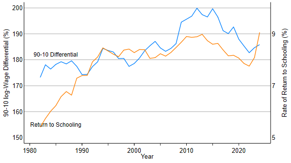

Inequality and Returns to Education

**Graph: Relationship between Inequality and Returns to Education**

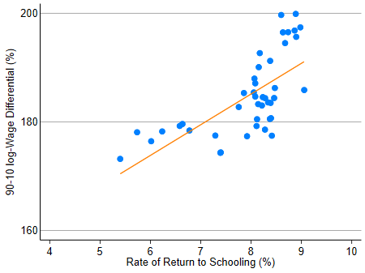

Scatter Plot

### Conclusion

This analysis demonstrates the evolving relationship between education and wage inequality from 1982 to 2024. The findings highlight how increasing returns to education have coincided with growing wage inequality, suggesting that changes in the value of education in the labor market may be an important driver of overall wage dispersion. The results also underscore the persistent role of demographic and structural factors in determining wages.